# Cvičenie 9: SARIMA modelovanie

Aby sme zachytili autokorelácie a parciálne autokorelácie na začiatku, musíme do modelu pridať klasické členy. Priebeh však nie je jednoznačný - zdá sa, že ani ACF ani PACF sa po niektorom lagu nevynuluje. Obe majú naviac výrazne nenulové prvé hodnoty. Skúsme preto použiť zmiešaný ARMA(1,1) model. Teda spolu so sezónnym MA členom, uvažujme model *ARMA(1,1) + sMA(1)*. Dostávame

```
## <><><><><><><><><><><><><><>
##
## Coefficients:
##      Estimate     SE t.value p.value
## ar1    0.1960 0.2475  0.7921  0.4298
## ma1   -0.5784 0.2132 -2.7127  0.0076
## sma1  -0.5643 0.0747 -7.5544  0.0000
##
## sigma^2 estimated as 0.001341097 on 128 degrees of freedom
##
## AIC = -3.678622  AICc = -3.677179  BIC = -3.59083
##
```

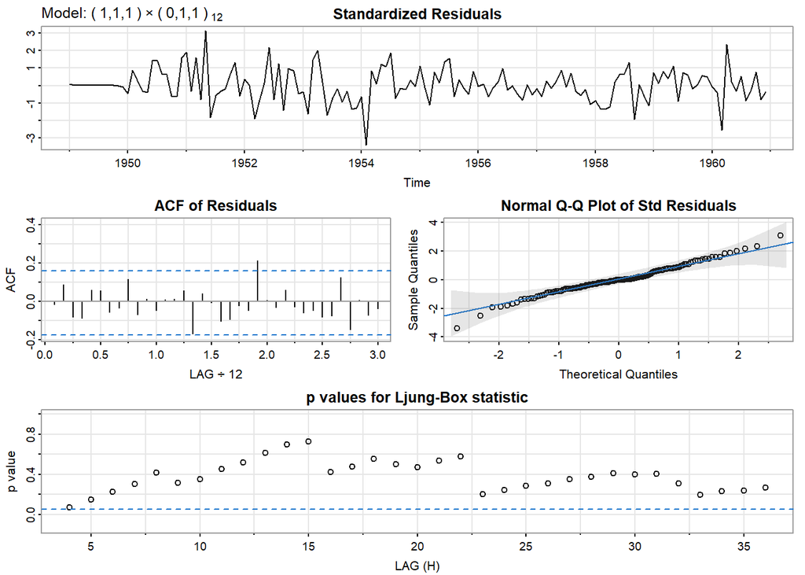

```r
sarima(x, 1, 1, 1, 0, 1, 1, 12)
```

Všetky p-hodnoty Ljung-Boxovho testu sú väčšie ako 5%. Model vyzerá dobre. Z tabuľky koeficientov však vidíme, že koeficient *ar1* nie je signifikantný (p.value = 0.4298), preto ho môžeme skúsiť vynechať.

```
## <><><><><><><><><><><><><><>
##
## Coefficients:
##      Estimate     SE t.value p.value
## ma1   -0.4018 0.0896 -4.4825       0
## sma1  -0.5569 0.0731 -7.6190       0
##
## sigma^2 estimated as 0.001348035 on 129 degrees of freedom
##
## AIC = -3.690069  AICc = -3.689354  BIC = -3.624225
##
```

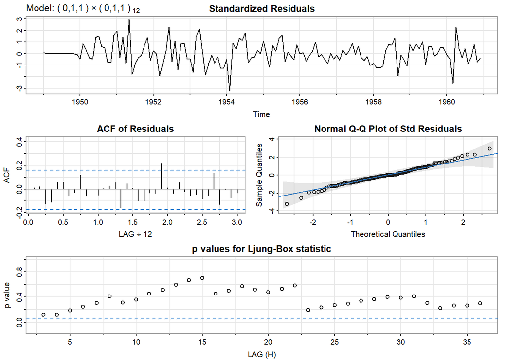

```r
sarima(x, 0, 1, 1, 0, 1, 1, 12)
```

P-hodnoty sa vylepšili, hodnota BIC klesla, oba koeficienty tohto modelu sú signifikantné. Dostali sme teda lepší model pre naše dáta. Uvedený model sa nazýva aj *airline model*.

Spravme predikcie na nasledujúce 2 roky.

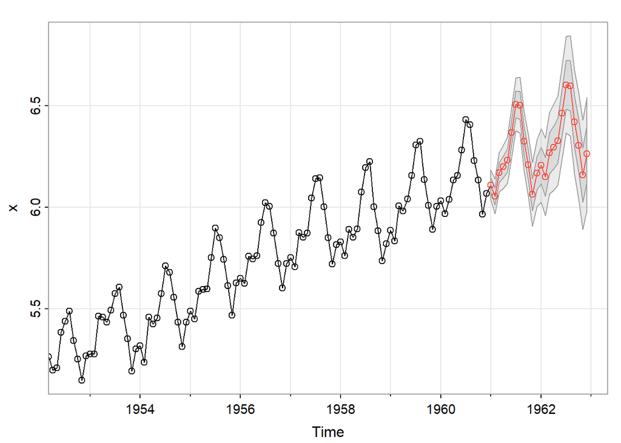

```r
sarima.for(x, 24, 0, 1, 1, 0, 1, 1, 12)
```

Vidíme, že sa zachováva rast aj pravidelná sezónnosť.

### 3.1.2 Dáta `chicken`

Nájdeme SARIMA model pre dáta *chicken* z prednášky.

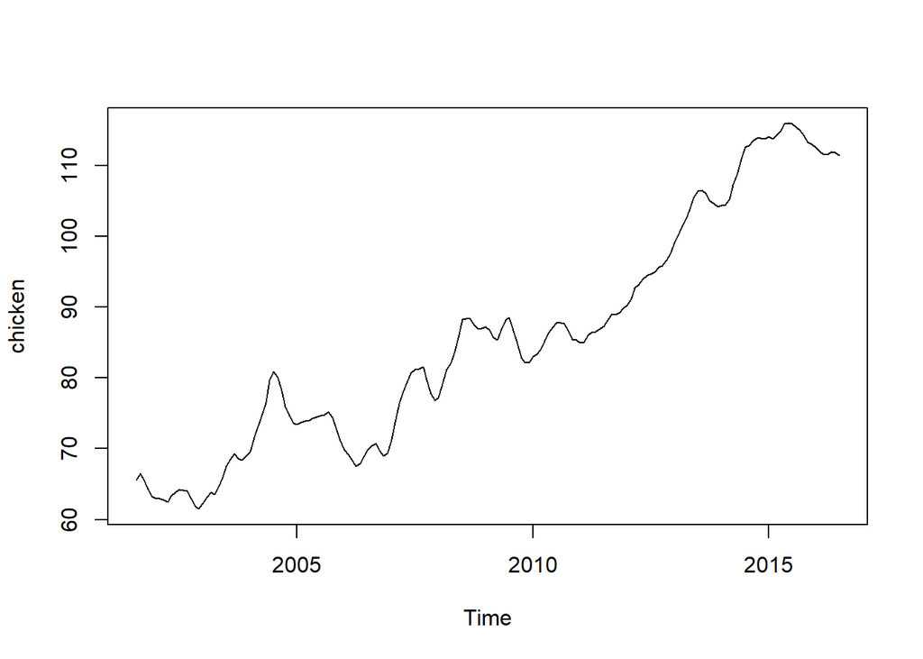

```r
data("chicken")
plot(chicken)
```

V dátach pozorujeme rastúci trend, preto dáta diferencujeme.

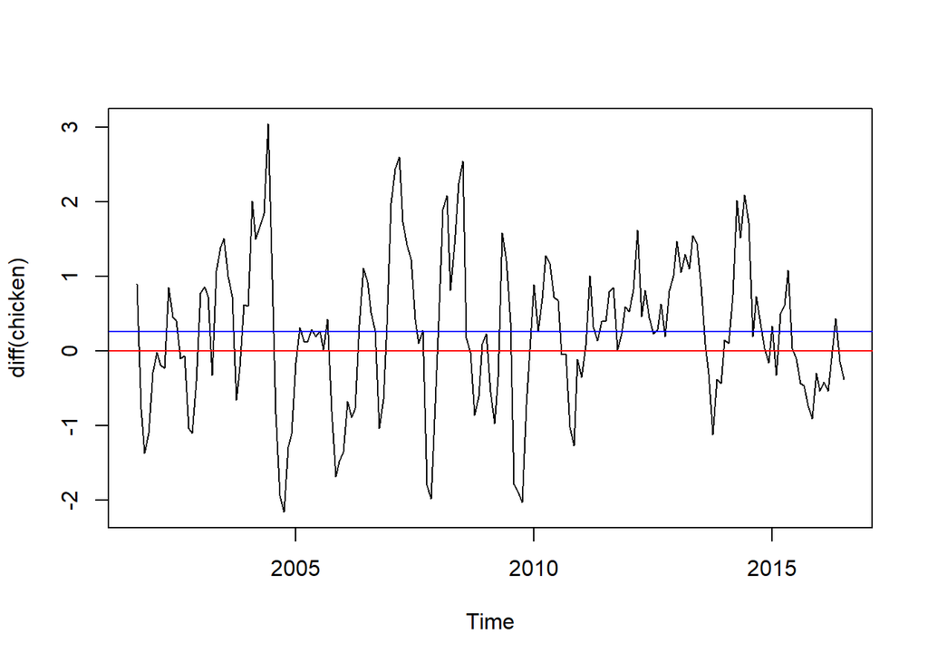

```r
plot(diff(chicken))
abline(h=0, col="red")
abline(h=mean(diff(chicken)), col="blue")
```

Zobrazme autokorelačnú funkciu pre diferencie.

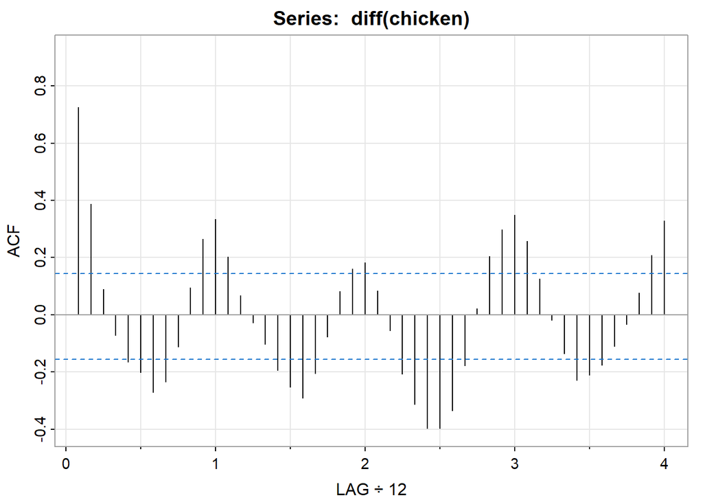

```r
acf1(diff(chicken))
```

Z ACF nie je zrejmé, či dáta majú jednotkový koreň. Otestujte ho.

```r
summary(ur.df(..., lag = ..., type = ..., selectlags = ...))
```

```
##
## ###############################################
## # Augmented Dickey-Fuller Test Unit Root Test #
## ###############################################
##
## Test regression drift
##
##
## Call:
## lm(formula = z.diff ~ z.lag.1 + 1 + z.diff.lag)
##
## Residuals:
##      Min       1Q   Median       3Q      Max
## -2.14194 -0.41020  0.03508  0.42470  1.68715
##
## Coefficients:
##             Estimate Std. Error t value Pr(>|t|)
## (Intercept)  0.10610    0.05407   1.962   0.0515 .
## z.lag.1     -0.35199    0.05458  -6.448 1.24e-09 ***
## z.diff.lag   0.30224    0.07438   4.063 7.52e-05 ***
## ---
## Signif. codes:  0 '***' 0.001 '**' 0.01 '*' 0.05 '.' 0.1 ' ' 1
##
## Residual standard error: 0.6642 on 162 degrees of freedom
## Multiple R-squared:  0.217,  Adjusted R-squared:  0.2074
## F-statistic: 22.45 on 2 and 162 DF,  p-value: 2.472e-09
##
##
## Value of test-statistic is: -6.4484 20.7942
##
## Critical values for test statistics:
##       1pct  5pct 10pct
## tau2 -3.46 -2.88 -2.57
## phi1  6.52  4.63  3.81
```

Mali by ste dostať, že v dátach skutočne nie je jednotkový koreň. Preto dáta ďalej nie je potrebné diferencovať.

Zobrazte ACF a PACF pre diferencie.

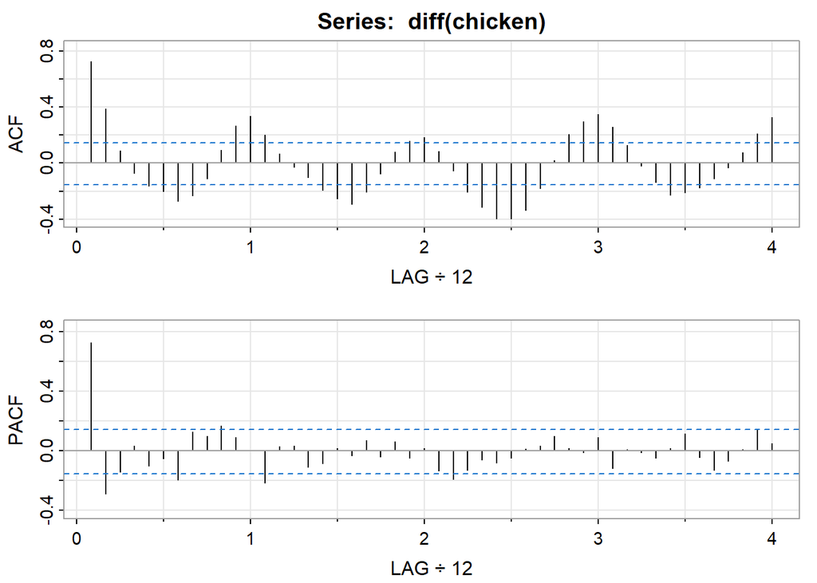

```r
acf2(diff(chicken))
```

ACF sa nevynuluje, má sínusový charakter. PACF má prvé dve hodnoty výrazne nenulové, tretia hodnota je na hranici. To je typické pre autoregresný proces. Očakávame preto buď AR(2) alebo AR(3).

PACF nemá výrazné hodnoty pri celých rokoch. Všimnime si však, že pravideľnosť priebehu ACF evidentne súvisí s celými rokmi. Preto očakávame prítomnosť sezónneho členu. Skúsme sezónny AR(1).

Otestujme ako prvý model AR(3) + sAR(1).

```
## <><><><><><><><><><><><><><>
##
## Coefficients:
##          Estimate     SE t.value p.value
## ar1        0.8885 0.0746 11.9031  0.0000
## ar2       -0.1459 0.0996 -1.4647  0.1448
## ar3       -0.1151 0.0750 -1.5352  0.1265
## sar1       0.3113 0.0724  4.2976  0.0000
## constant   0.2387 0.1735  1.3760  0.1706
##
## sigma^2 estimated as 0.3779479 on 174 degrees of freedom
##
## AIC = 1.944065  AICc = 1.946002  BIC = 2.050905
##
```

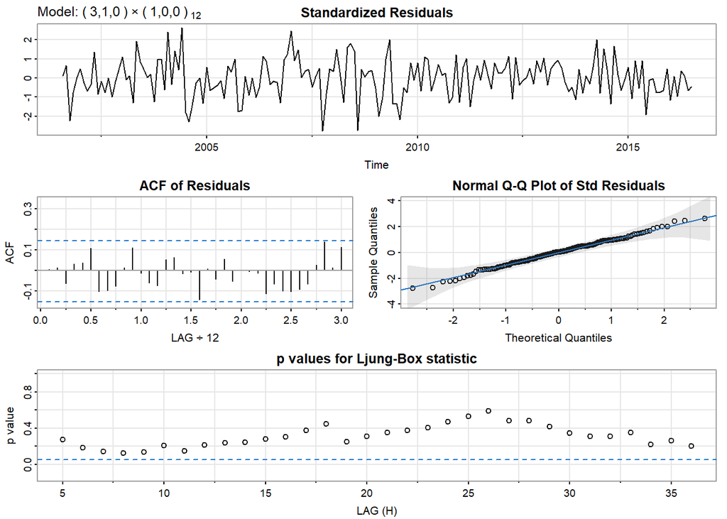

```r
sarima(chicken, 3, 1, 0, 1, 0, 0, 12)
```

Model vyzerá dobre, ale v tabuľke koeficientov si môžeme všimnúť, že koeficient *ar3* nie je signifikantný. Znížme preto počet klasických AR členov na 2.

```
## <><><><><><><><><><><><><><>
##
## Coefficients:
##          Estimate     SE t.value p.value
## ar1        0.9154 0.0733 12.4955  0.0000
## ar2       -0.2494 0.0739 -3.3728  0.0009
## sar1       0.3237 0.0715  4.5238  0.0000
## constant   0.2353 0.1973  1.1923  0.2347
##
## sigma^2 estimated as 0.3828137 on 175 degrees of freedom
##
## AIC = 1.945971  AICc = 1.947256  BIC = 2.035005
##
```

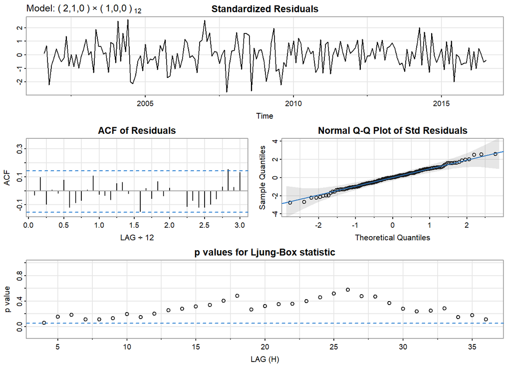

```r
sarima(chicken, 2, 1, 0, 1, 0, 0, 12)
```

Všetky p-hodnoty sú stále nad 5%. Model je vyhovujúci.

Uvedené modely môžeme porovnať aj na základe BIC, pričom volíme model s nižším BIC. V našom prípade je to model `sarima(chicken, 2, 1, 0, 1, 0, 0, 12)`. Pre tento model urobme predikcie na nasledujúci rok.

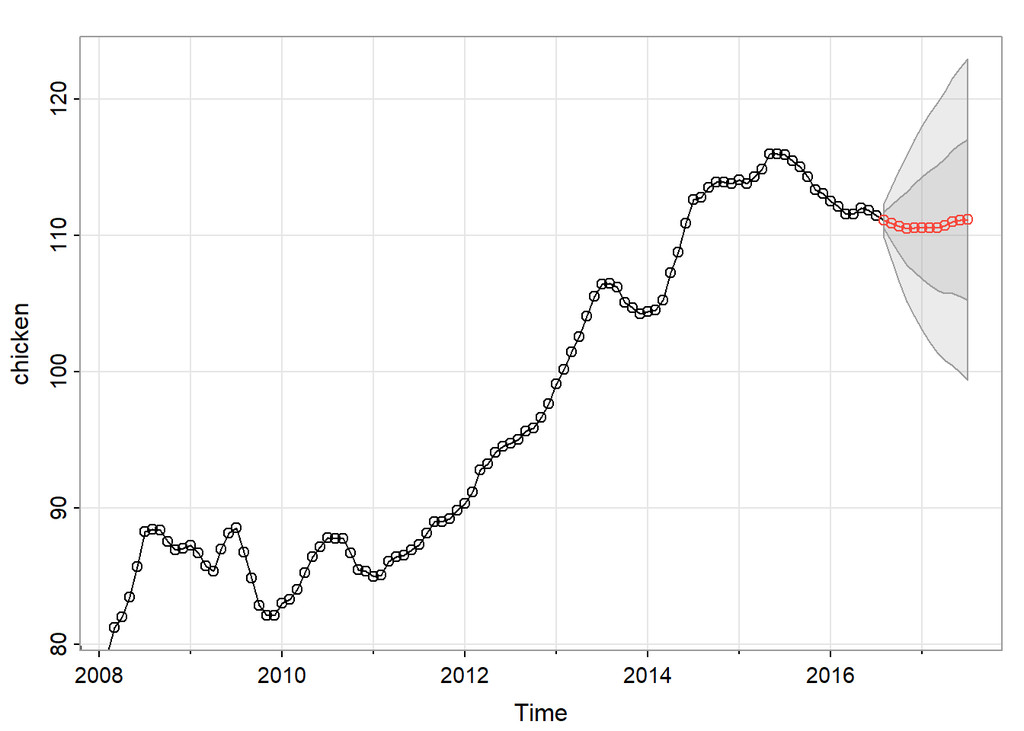

```r
sarima.for(chicken, 12, 2, 1, 0, 1, 0, 0, 12)
```

Konkrétne budeme modelovať dáta v sektore Leisure and Hospitality (rekreácia a pohostinstvo) od januára 2001 do septembra 2019. Z dát vytvoríme časový rad.

```r
leisure <- us_employment %>%
  filter(Title == "Leisure and Hospitality",
         year(Month) > 2000) %>%
  mutate(Employed = Employed/1000) %>%
  select(Month, Employed)

leisure <- ts(leisure$Employed, start = c(2001,1), end = c(2019,9),
              frequency = 12)
```

Do premennej `leisure.pred` si odložíme posledný rok dát na zhodnotenie predikcií. Pri modelovaní budeme preto pracovať s časovým radom skráteným o tento jeden rok.

```r
leisure.pred <- window(leisure, start = ... )
leisure <- window(leisure, end = ... )
```

Priebeh časového radu:

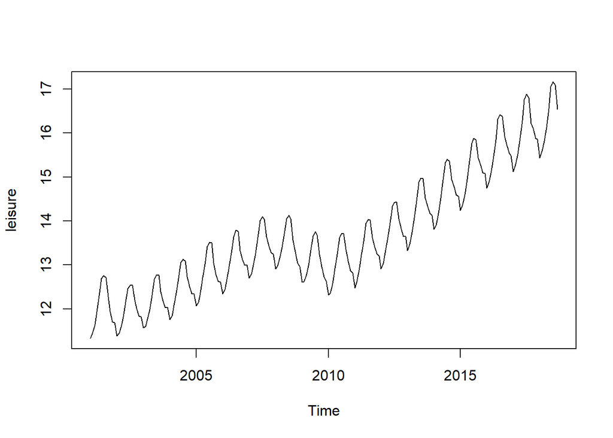

**Zodpovedajte otázky:**

- Sú dáta stacionárne?
- Je v dátach prítomný trend?
- Pozorujeme v dátach sezónnosť?
- Je potrebné dáta diferencovať? Ak áno, sezónne alebo klasicky? Koľkokrát?

Pre stacionárne dáta, ktoré už netreba diferencovať, by ste mali dostať nasledovnú ACF a PACF.

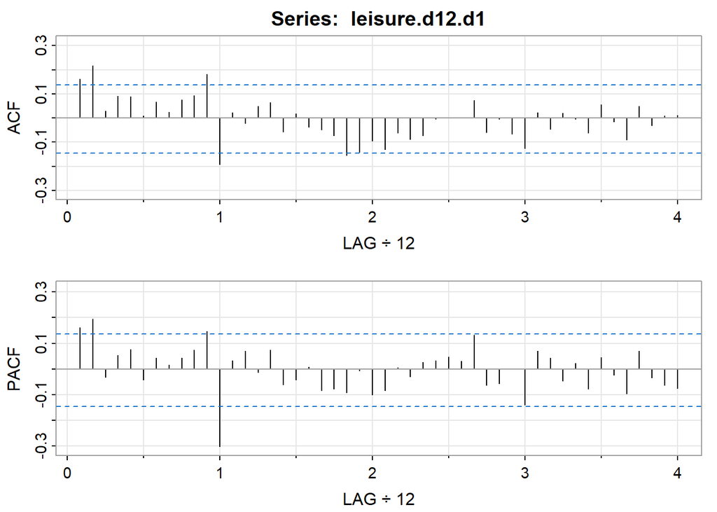

```r
acf2(leisure.d12.d1)
```

- Aké tipy na sarima modely máte na základe ACF a PACF?
- Určte najlepší z vyhovujúcich modelov na základe BIC.
- Pre najlepší z modelov spravte predikcie na jeden rok. Porovnajte s reálnymi dátami odloženými v premennej `leisure.pred`.

Výsledok pre porovnanie:

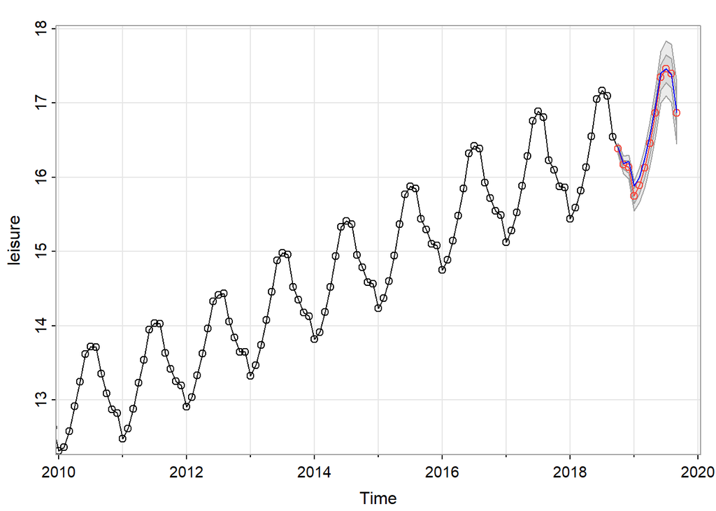

## 3.3 Harmonizovaný index spotrebiteľských cien na Slovensku

Analyzujme harmonizovaný index spotrebiteľských cien (HICP) na Slovensku. HICP je štatistický ukazovateľ používaný na meranie inflácie, resp. zmien v cenovej hladine spotrebiteľských tovarov a služieb. Tento index je štandardizovaný pre krajiny Európskej únie a ďalšie štáty, aby umožnil porovnanie medzi krajinami.

Zdroj dát: https://fred.stlouisfed.org/series/CP0000SKM086NEST

Dáta môžete do R-ka jednoducho načítať príkazom

```r
HICP.SK <- read.table("https://anna-hlubinova.github.io/HICP_Slovakia.txt", header = TRUE)
head(HICP.SK)
```

```
##       DATE Value
## 1 1.1.1996 43.01
## 2 1.2.1996 43.12
## 3 1.3.1996 43.22
## 4 1.4.1996 43.35
## 5 1.5.1996 43.56
## 6 1.6.1996 43.63
```

Vytvorte z dát časový rad. Dáta za rok 2024 odložte do premennej `hicp.pred`. Pomocou týchto dát zhodnotíme predikcie. Pri modelovaní budeme pracovať so skráteným časovým radom do konca roka 2023.

```r
hicp.ts <- ts(... , frequency = ..., start = ...)

hicp <- window(hicp.ts, end = ...)
hicp.pred <- window(hicp.ts , start = ...)
```

Priebeh časového radu:

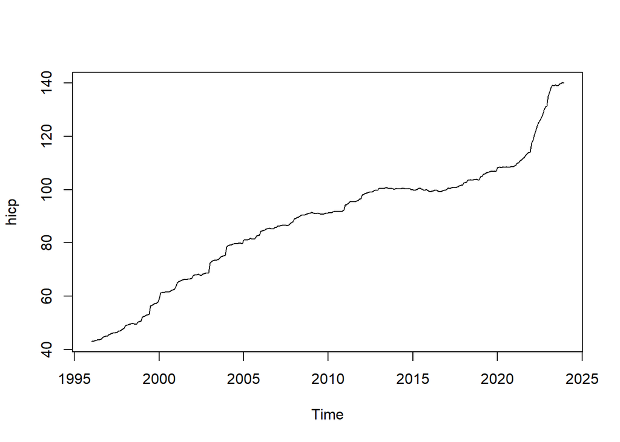

```r
plot(hicp, type = "l")
```

**Zodpovedajte otázky:**

- Sú dáta stacionárne?
- Je v dátach prítomný trend?
- Pozorujeme v dátach sezónnosť?
- Je potrebné dáta diferencovať? Ak áno, sezónne alebo klasicky? Koľkokrát?

Pre stacionárne dáta, ktoré ďalej netreba diferencovať, by ste mali dostať nasledovnú ACF a PACF.

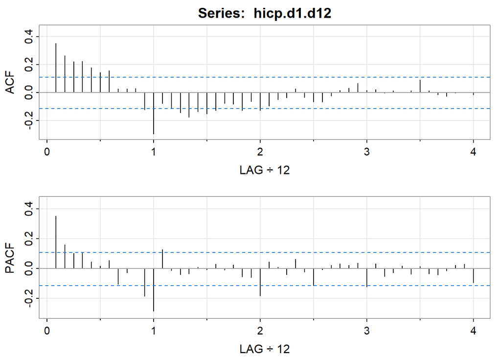

```r
acf2(hicp.d1.d12)
```

- Aké tipy na sarima model máte na základe ACF a PACF?
- Určte najlepší z vyhovujúcich modelov na základe BIC.
- Pre najlepší z modelov spravte predikcie na jeden rok. Porovnajte s reálnymi dátami odloženými v premennej `hicp.pred`.

Výsledok pre porovnanie:

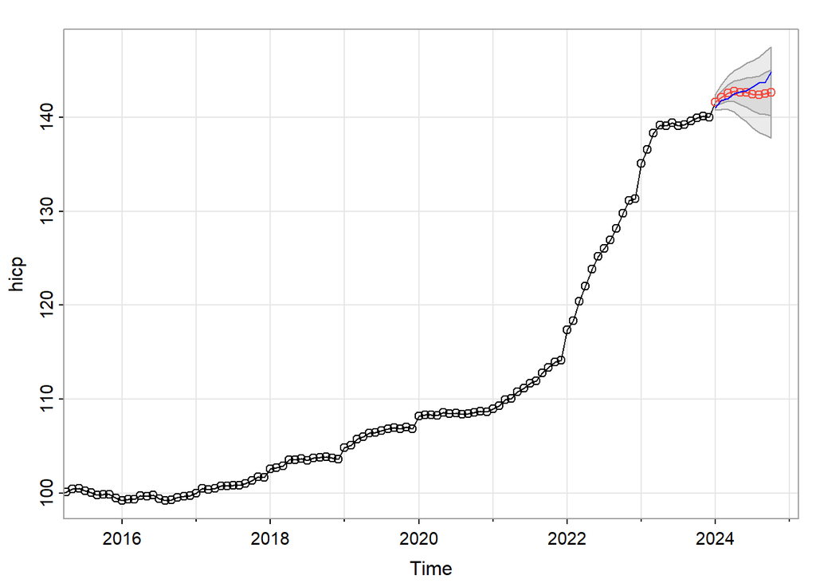

## 3.4 Dáta *exp* o čínskom exporte

Pozrime sa ďalej na dáta *exp* o čínskom exporte z knižnice `seasonal`.

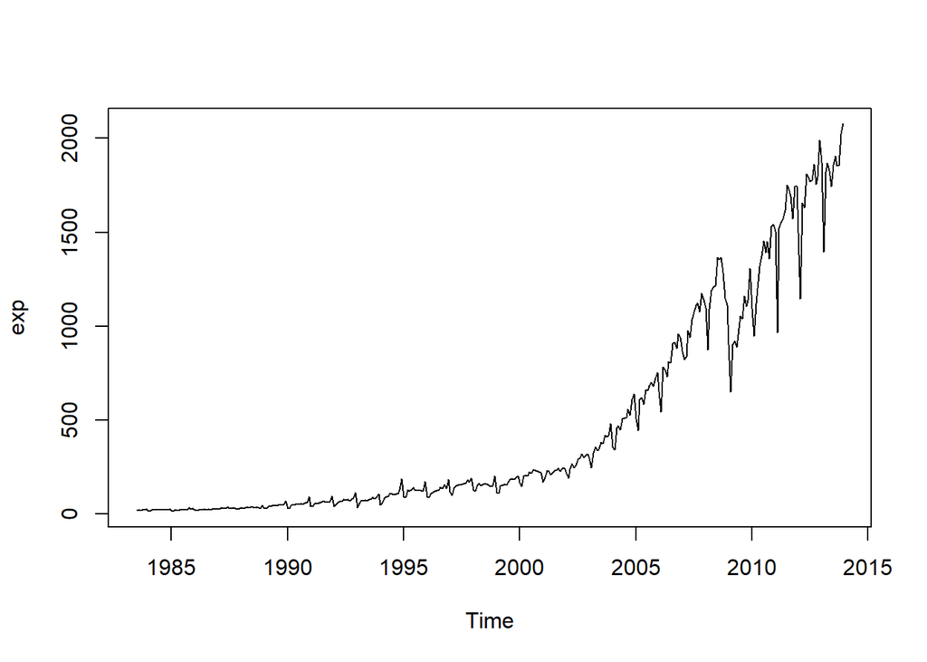

```r
plot(exp)
```

```r
x <- window(..., start= ... , end = ... )
x.pred <-  window(..., start=...)
```

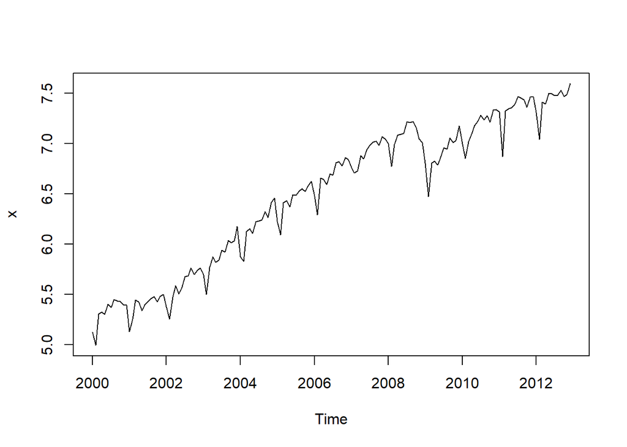

```r
plot(x)
```

**Zodpovedajte otázky:**

- Sú dáta stacionárne?
- Je v dátach prítomný trend?
- Pozorujeme v dátach sezónnosť?
- Je potrebné dáta diferencovať? Ak áno, sezónne alebo klasicky? Koľkokrát?

Pre stacionárne dáta, ktoré ďalej netreba diferencovať, by ste mali dostať nasledovnú ACF a PACF.

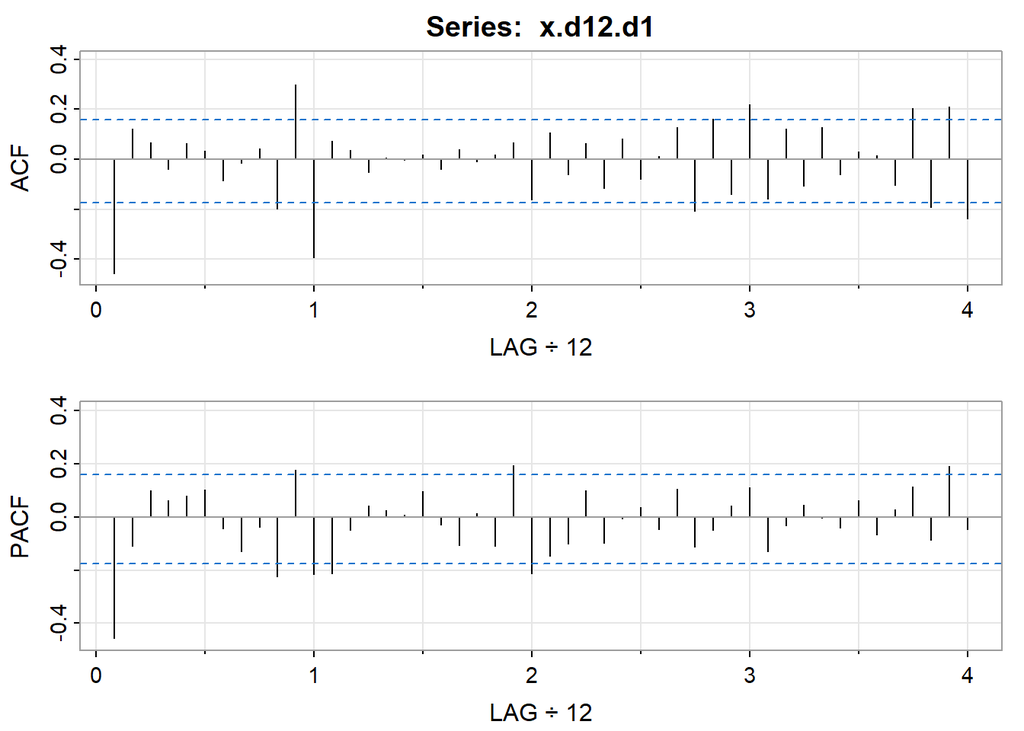

```r
acf2(x.d12.d1)
```

- Aké tipy na sarima modely máte na základe ACF a PACF?
- Určte najlepší z vyhovujúcich modelov na základe BIC.
- Pre najlepší z modelov spravte predikcie na jeden rok. Porovnajte s reálnymi dátami odloženými v premennej `x.pred`.

Výsledok pre porovnanie:

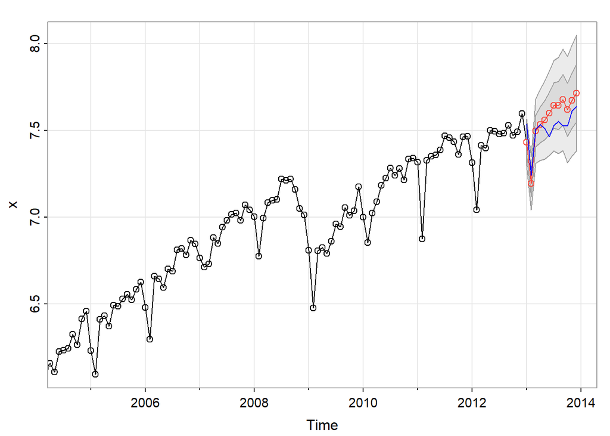